# Project #2

## e) Fourth candidate model: Using ridge regression

### Determining the best $\lambda$ value

```r
# need to split into x and y for glmnet
train_x = model.matrix(price~., train)
train_y = train$price
test_x = model.matrix(price~., test)
test_y = test$price
```

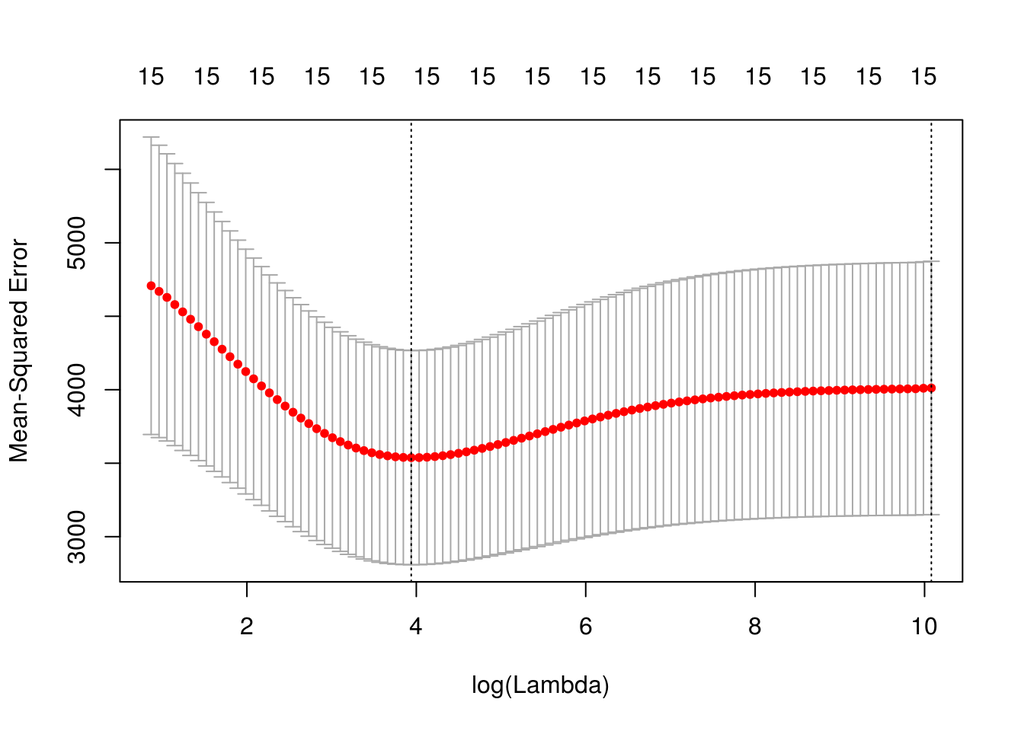

```r
set.seed(111)
cv.out = cv.glmnet(train_x, train_y, alpha = 0)
plot(cv.out)
```

- It appears that the best log(Lambda) value is ~4

```r
ridge_bestlam = cv.out$lambda.min
ridge_bestlam
```

```
## [1] 51.41695
```

### Building our model

```r
ridge.mod = glmnet(train_x, train_y, alpha=0, lambda=ridge_bestlam, thresh=1e-12)
```

## f) Using partial least squares regression

### Using cross validation to determine the number of components.

```r
set.seed(111)
plsr_housing = plsr(price~., data=housing, subset = trainIndex, scale=TRUE, validation="CV", ncomp = 13)
```

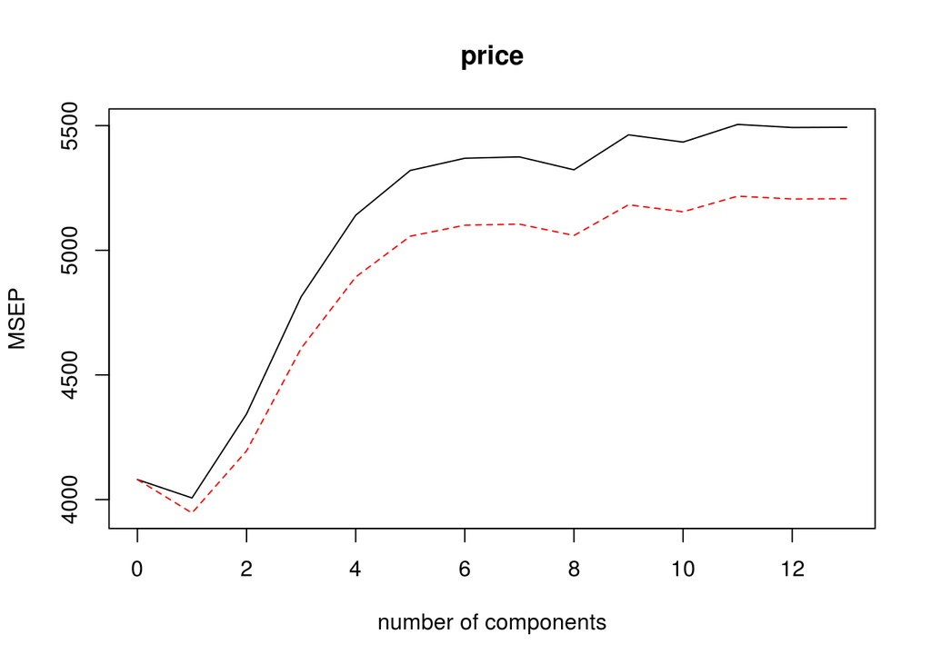

```r
validationplot(plsr_housing,val.type="MSEP")
```

- The graph shows that the MSEP is minimized below 2.
- I will choose 1 for the number of components

## g) Evaluating our models

### Calculating the MSE for predicting test data

```r
first_pred <- predict(model_one, test)
first_error <- mean((first_pred-test_y)^2)

second_pred <- predict(model_two, test)
second_error <- mean((second_pred - test_y)^2)

third_pred <- predict(model_three, test)
third_error <- mean((third_pred - test_y)^2)

plsr_pred = predict(plsr_housing, test, ncomp = 1)
plsr_error <- mean((plsr_pred-test_y)^2)

ridge_pred = predict(ridge.mod, s = ridge_bestlam, newx = test_x)
ridge_error <- mean((ridge_pred-test_y)^2)

cbind(first_error, second_error, third_error, ridge_error, plsr_error)
```

```
##      first_error second_error third_error ridge_error plsr_error
## [1,]     2072.87     1478.651    1804.591    1940.812   1859.296
```

### Calculating R squared values

```r
rsq = function (predicted, actual) {
  return(1 - (sum((predicted - actual) ^ 2)/sum((actual - mean(actual)) ^ 2) ))
}

second_rsq <- rsq(second_pred, test_y)
third_rsq <- rsq(third_pred, test_y)
first_rsq <- rsq(first_pred, test_y)
plsr_rsq <- rsq(plsr_pred, test_y)
ridge_rsq <- rsq(ridge_pred, test_y)

cbind(second_rsq, plsr_rsq, third_rsq, ridge_rsq, first_rsq)
```

```
##      second_rsq  plsr_rsq third_rsq ridge_rsq first_rsq
## [1,]   0.553175 0.4381502 0.4546811 0.4135174 0.3736115
```

- Our R-squared values range from 0.55 to 0.37, with the second model having the highest.

### Explanation of our final model/the model that we prefer

```r
summary(model_two)
```

```
##
## Call:
## lm(formula = price ~ size + lot + bedrooms + garagesize + status +
##     elem, data = housing)
##
## Residuals:
##     Min      1Q  Median      3Q     Max
## -91.638 -29.448  -1.418  26.074 105.480
##
## Coefficients:
##             Estimate Std. Error t value Pr(>|t|)
## (Intercept)  114.474     54.760   2.090  0.04055 *
## size          80.711     27.633   2.921  0.00482 **
## lot           10.047      3.532   2.845  0.00596 **
## bedrooms     -12.405      8.564  -1.449  0.15235
## garagesize     9.633      8.685   1.109  0.27149
## statuspen    -19.833     16.211  -1.223  0.22566
## statussld    -37.997     13.723  -2.769  0.00735 **
## elemcrest      1.698     33.706   0.050  0.95998
## elemedge       6.138     28.572   0.215  0.83059
## elemedison    82.385     29.561   2.787  0.00700 **
## elemharris    53.632     29.951   1.791  0.07808 .
## elemparker   -14.254     29.637  -0.481  0.63220
## ---
## Signif. codes:  0 '***' 0.001 '**' 0.01 '*' 0.05 '.' 0.1 ' ' 1
##
## Residual standard error: 44.46 on 64 degrees of freedom
## Multiple R-squared:  0.5366, Adjusted R-squared:  0.457
## F-statistic: 6.738 on 11 and 64 DF,  p-value: 2.292e-07
```

- It is clear that our second model is the best model to use.
  - It maximizes the R-squared value at 0.5366. This means that we are explaining over half of the variation with this model.
  - It also minimizes the MSE, and only has 6 variables in it, which means it is easier to understand.
- We built this model using regsubsets via backwards selection, so we removed the unneeded predictors.
- This model also has a statistically significant p-value, and a decent F statistic.